# Report: GAMMs of Biomarkers

Daniel J. Naumenko

2022-10-24

Following the EDA report, I will do some straightforward GAMMs of each biomarker against the others.

https://cran.r-project.org/web/packages/gratia/vignettes/gratia.html

### 8-OHdG ~ TAC

```
##
## Family: gaussian
## Link function: identity
##
## Formula:
## ohdg_include ~ s(tac_include)
##
## Parametric coefficients:
##             Estimate Std. Error t value Pr(>|t|)
## (Intercept)  20.0146     0.8668   23.09   <2e-16 ***
## ---
## Signif. codes:  0 '***' 0.001 '**' 0.01 '*' 0.05 '.' 0.1 ' ' 1
##
## Approximate significance of smooth terms:
##                  edf Ref.df     F  p-value
## s(tac_include) 2.484  2.484 10.34 1.75e-05 ***
## ---
## Signif. codes:  0 '***' 0.001 '**' 0.01 '*' 0.05 '.' 0.1 ' ' 1
##
## R-sq.(adj) =  0.0554
##   Scale est. = 175.91    n = 425
```

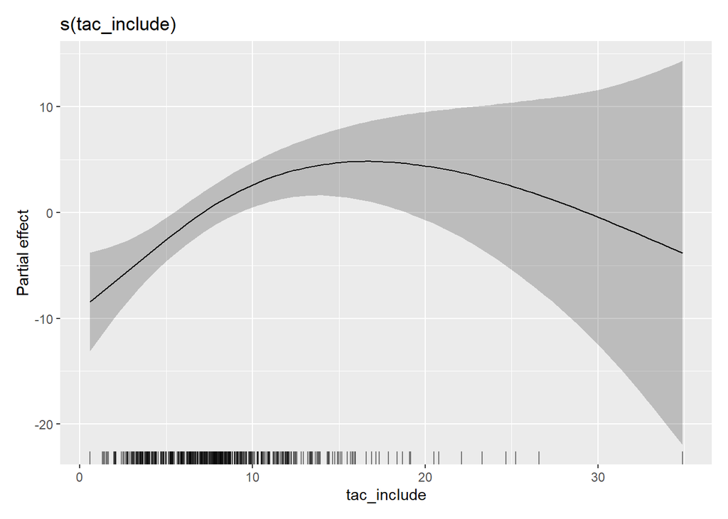

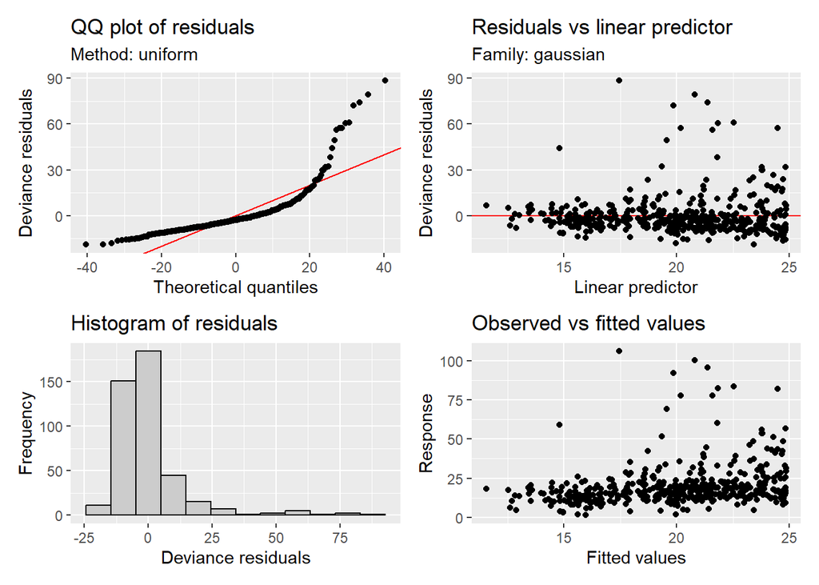

Definitely need to adjust and refit this model, probably by adjusting the family. Look at what you did for AABA 2022 to determine what link family to use.

```
##
## Family: gaussian
## Link function: identity
##
## Formula:
## ohdg_include ~ s(tac_include)
##
## Parametric coefficients:
##             Estimate Std. Error t value Pr(>|t|)
## (Intercept)  20.0956     0.8664   23.19   <2e-16 ***
## ---
## Signif. codes:  0 '***' 0.001 '**' 0.01 '*' 0.05 '.' 0.1 ' ' 1
##
## Approximate significance of smooth terms:
##                  edf Ref.df     F  p-value
## s(tac_include) 2.042  2.042 11.91 9.17e-06 ***
## ---
## Signif. codes:  0 '***' 0.001 '**' 0.01 '*' 0.05 '.' 0.1 ' ' 1
##
## R-sq.(adj) =  0.0526
##   Scale est. = 176.69    n = 422
```

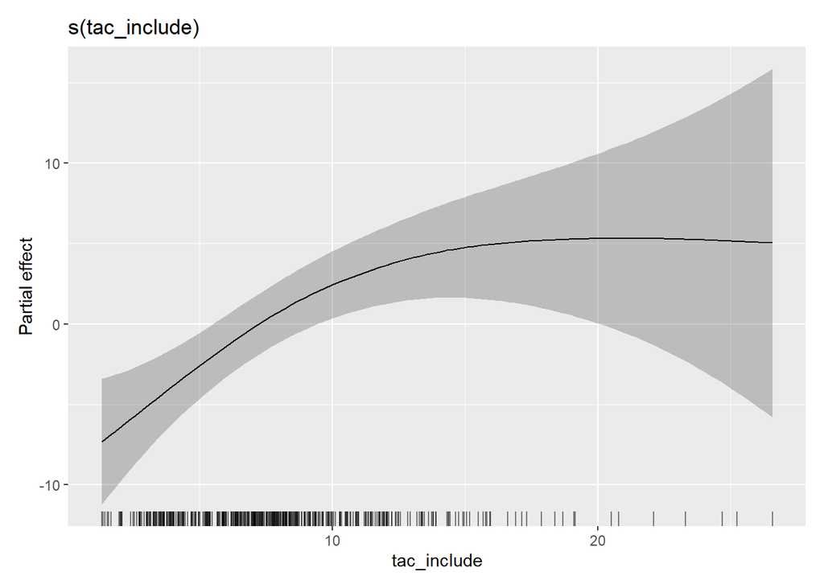

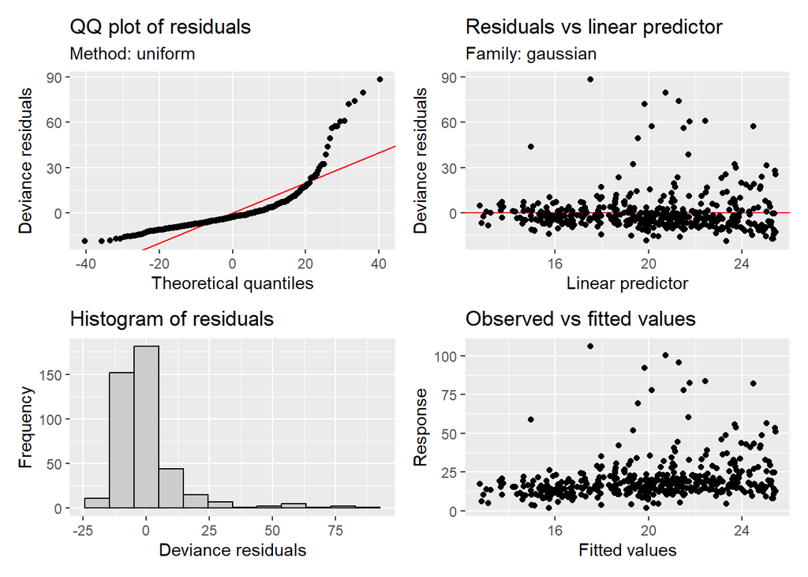

Still need to adjust the distribution of stuff. Will want to run with link functions with and without distances removed.

#### 8-OHdG and Neopterin

```
##
## Family: gaussian
## Link function: identity
##
## Formula:
## ohdg_include ~ s(neop_include)
##
## Parametric coefficients:
##             Estimate Std. Error t value Pr(>|t|)
## (Intercept)  19.2384     0.6989   27.53   <2e-16 ***
## ---
## Signif. codes:  0 '***' 0.001 '**' 0.01 '*' 0.05 '.' 0.1 ' ' 1
##
## Approximate significance of smooth terms:
##                   edf Ref.df     F p-value
## s(neop_include) 5.472  5.472 49.49  <2e-16 ***
## ---
## Signif. codes:  0 '***' 0.001 '**' 0.01 '*' 0.05 '.' 0.1 ' ' 1
##
## R-sq.(adj) =  0.354
##   Scale est. = 122.29    n = 480
```

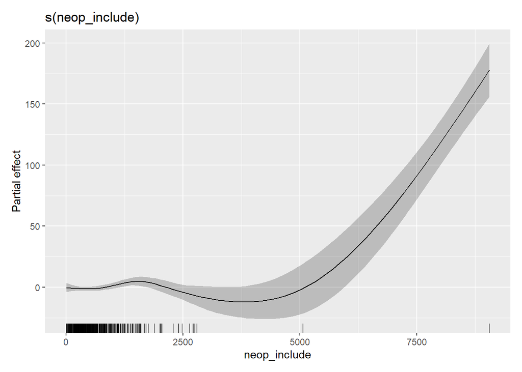

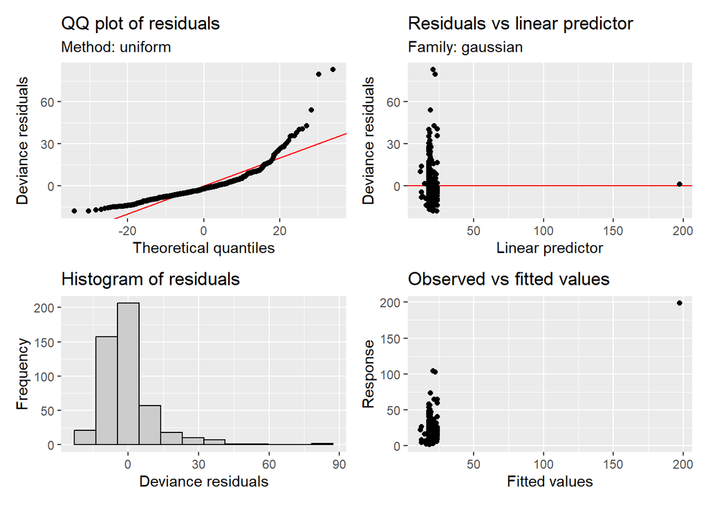

So there is an intense outlier, potentially two, that should definitely be removed. I will also want to adjust the link family.

```
##
## Family: gaussian
## Link function: identity
##
## Formula:
## ohdg_include ~ s(neop_include)
##
## Parametric coefficients:
##             Estimate Std. Error t value Pr(>|t|)
## (Intercept)  18.8843     0.6931   27.25   <2e-16 ***
## ---
## Signif. codes:  0 '***' 0.001 '**' 0.01 '*' 0.05 '.' 0.1 ' ' 1
##
## Approximate significance of smooth terms:
##                   edf Ref.df     F p-value
## s(neop_include) 3.154  3.154 3.625   0.012 *
## ---
## Signif. codes:  0 '***' 0.001 '**' 0.01 '*' 0.05 '.' 0.1 ' ' 1
##
## R-sq.(adj) =  0.0259
##   Scale est. = 122.54    n = 477
```

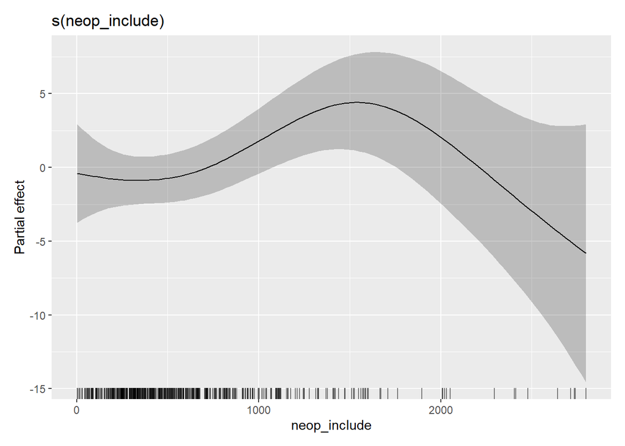

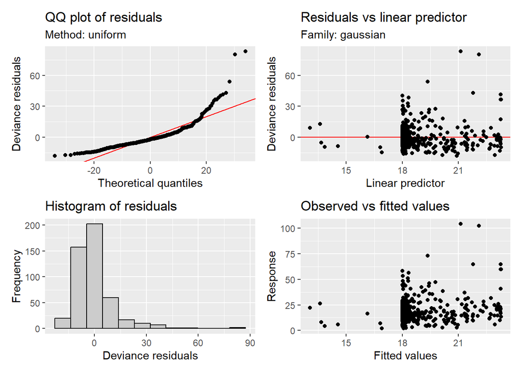

Still some outliers and distribution stuff that needs to be worked out. However, we see an increase between the two, and then we see them tank. I wonder why this odd relationship exists. Perhaps high neopterin/8-OHdG stimulates higher TAC, resulting in lower 8-OHdG. or the longer one is exposed…need to explore this but not sure how.

```
##
## Family: gaussian
## Link function: identity
##
## Formula:
## tac_include ~ s(neop_include)
##
## Parametric coefficients:
##             Estimate Std. Error t value Pr(>|t|)
## (Intercept)   8.0921     0.3058   26.46   <2e-16 ***
## ---
## Signif. codes:  0 '***' 0.001 '**' 0.01 '*' 0.05 '.' 0.1 ' ' 1
##
## Approximate significance of smooth terms:
##                 edf Ref.df     F p-value
## s(neop_include)   1      1 2.725  0.0998 .
## ---
## Signif. codes:  0 '***' 0.001 '**' 0.01 '*' 0.05 '.' 0.1 ' ' 1
##
## R-sq.(adj) =  0.0061
##   Scale est. = 18.097    n = 322
```

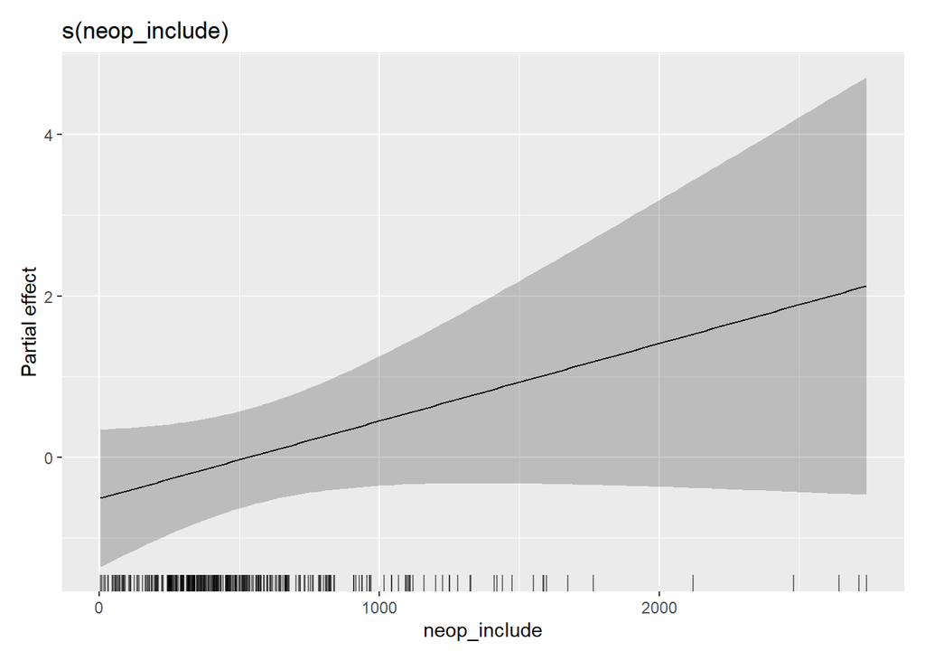

Ok, so it appears there is a linear relationship between these two variables, so I will run a glmm.

```
## Linear mixed model fit by REML ['lmerMod']
## Formula: tac_include ~ neop_include + (1 | Orangutan_ID)
##    Data: urine_df
##
## REML criterion at convergence: 1872.3
##
## Scaled residuals:
##     Min      1Q  Median      3Q     Max
## -2.1019 -0.6815 -0.1375  0.4789  3.9482
##
## Random effects:
##  Groups       Name        Variance Std.Dev.
##  Orangutan_ID (Intercept)  1.04    1.02
##  Residual                 18.15    4.26
## Number of obs: 322, groups:  Orangutan_ID, 44
##
## Fixed effects:
##               Estimate Std. Error t value
## (Intercept)  7.5843189  0.4405767  17.215
## neop_include 0.0009550  0.0005826   1.639
##
## Correlation of Fixed Effects:
##             (Intr)
## neop_includ -0.706
```

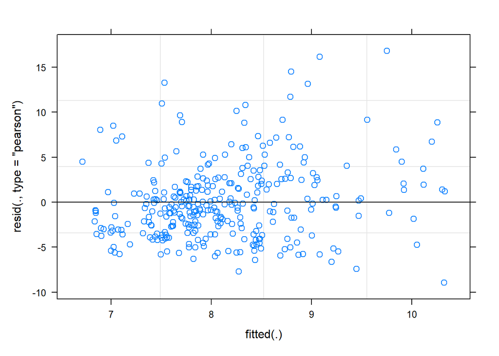

#### 8-OHdG and Cortisol

```
##
## Family: gaussian
## Link function: identity
##
## Formula:
## ohdg_include ~ s(cort_include)
##
## Parametric coefficients:
##             Estimate Std. Error t value Pr(>|t|)
## (Intercept)  20.7442     0.9582   21.65   <2e-16 ***
## ---
## Signif. codes:  0 '***' 0.001 '**' 0.01 '*' 0.05 '.' 0.1 ' ' 1
##
## Approximate significance of smooth terms:
##                   edf Ref.df    F p-value
## s(cort_include) 2.008  2.008 4.79 0.00928 **
## ---
## Signif. codes:  0 '***' 0.001 '**' 0.01 '*' 0.05 '.' 0.1 ' ' 1
##
## R-sq.(adj) =  0.0216
##   Scale est. = 263.04    n = 410
```

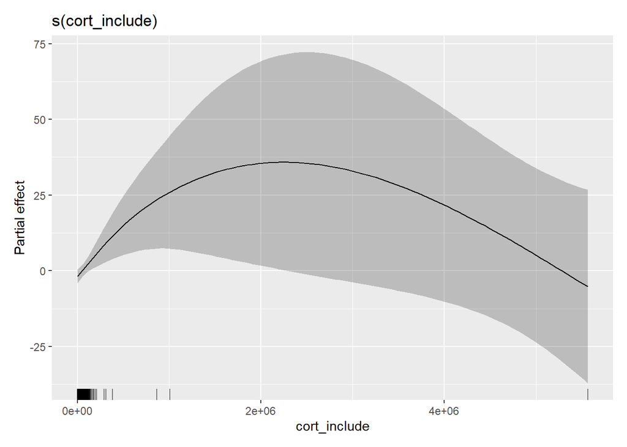

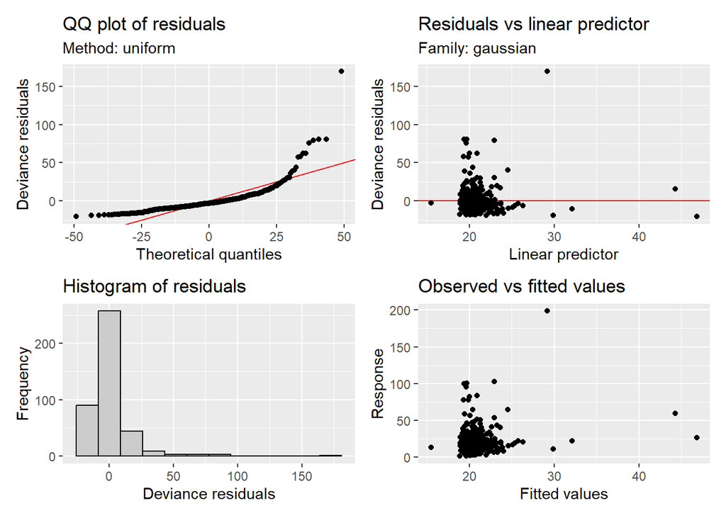

A few outliers to pay attention to removing.

#### 8-OHdG and ELBM

```
##
## Family: gaussian
## Link function: identity
##
## Formula:
## ohdg_include ~ s(elbm)
##
## Parametric coefficients:
##             Estimate Std. Error t value Pr(>|t|)
## (Intercept)   22.407      1.049   21.36   <2e-16 ***
## ---
## Signif. codes:  0 '***' 0.001 '**' 0.01 '*' 0.05 '.' 0.1 ' ' 1
##
## Approximate significance of smooth terms:
##          edf Ref.df    F p-value
## s(elbm) 5.77   5.77 8.29  <2e-16 ***
## ---
## Signif. codes:  0 '***' 0.001 '**' 0.01 '*' 0.05 '.' 0.1 ' ' 1
##
## R-sq.(adj) =  0.0996
##   Scale est. = 321.86    n = 457
```

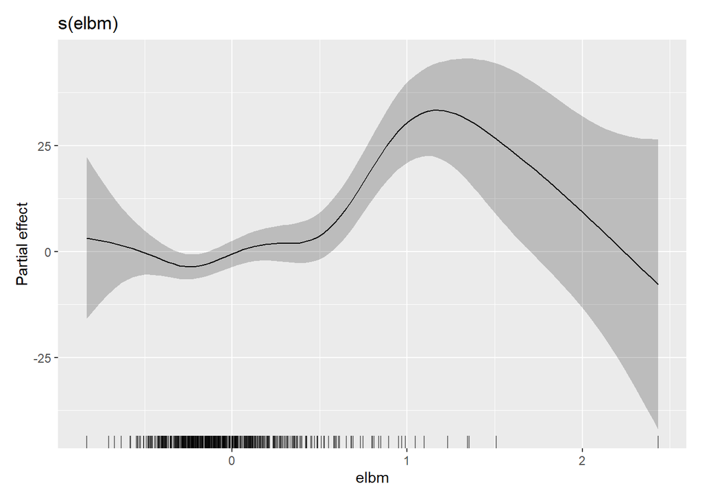

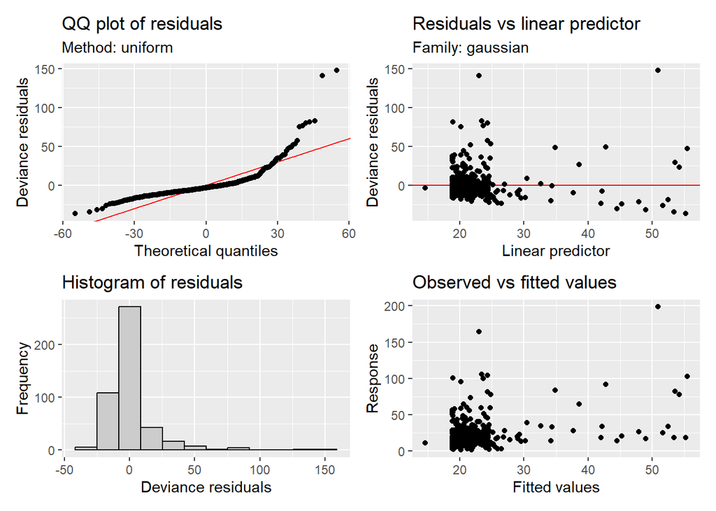